# DATA624-HW7-Linear-Regression

Kuhn-Johnson exercises 6.2, 6.3

Michael Y.

4/5/2020

# Homework 7 - Linear Regression

In Kuhn and Johnson do problems 6.2 and 6.3. There are only two but they consist of many parts.

Please submit a link to your Rpubs and submit the .rmd file as well.

```r
knitr::opts_chunk$set(echo = TRUE)
library(caret)
library(kableExtra)
library(AppliedPredictiveModeling)
library(moments)
library(pls)
library(VIM)
library(mice)
library(olsrr)
```

```r
library(corrplot)
options(scipen = 999, digits=7)
```

## 6.2. Developing a model to predict permeability

#### Description

This pharmaceutical data set was used to develop a model for predicting compounds’ **permeability**.

In short, **permeability** is the measure of a molecule’s ability to cross a **membrane.**

The body, for example, has notable membranes between the body and brain, known as the **blood-brain barrier**, and between the gut and body in the intestines.

These membranes help the body guard critical regions from receiving undesirable or detrimental substances.

For an orally taken drug to be effective in the brain, it first must pass through the intestinal wall and then must pass through the blood-brain barrier in order to be present for the desired neurological target.

Therefore, a compound’s ability to permeate relevant biological membranes is critically important to understand early in the drug discovery process.

Compounds that appear to be effective for a particular disease in research screening experiments, but appear to be poorly permeable may need to be altered in order improve permeability, and thus the compound’s ability to reach the desired target.

Identifying permeability problems can help guide chemists towards better molecules.

**Permeability assays** such as **PAMPA** and **Caco-2** have been developed to help measure compounds’ permeability (Kansy et al, 1998).

These screens are effective at quantifying a compound’s permeability, but the assay is expensive labor intensive.

Given a sufficient number of compounds that have been screened, we could develop a **predictive model for permeability** in an attempt to potentially reduce the need for the assay.

In this project there were **165 unique compounds**; **1107 molecular fingerprints** were determined for each.

A **molecular fingerprint** is a binary sequence of numbers that represents the **presence or absence** of a specific molecular sub-structure.

The **response** is **highly skewed**,  
the **predictors** are **sparse** (15.5 percent are present), and  
many predictors are **strongly associated**.

Usage  
`data(permeability)`  
Value

- `permeability`: permeability values for each compound. (A vector of 165 numbers.)
- `fingerprints`: a 165x1107 matrix of binary fingerprint indicator variables.

### (a) Start R and use these commands to load the data:

```r
library(AppliedPredictiveModeling)
data(permeability)
```

- The matrix `fingerprints` contains the 1,107 binary molecular predictors for the 165 compounds, while
- `permeability` contains permeability response.

#### Examine the permeability data

```r
# dim
dim(permeability)
```

```
## [1] 165   1
```

```r
N=length(permeability)
# str
str(permeability)
```

```
##  num [1:165, 1] 12.52 1.12 19.41 1.73 1.68 ...
##  - attr(*, "dimnames")=List of 2
##   ..$ : chr [1:165] "1" "2" "3" "4" ...
##   ..$ : chr "permeability"
```

```r
# head
head(permeability)
```

```
##   permeability
## 1       12.520
## 2        1.120
## 3       19.405
## 4        1.730
## 5        1.680
## 6        0.510
```

```r
# tail
tail(permeability)
```

```
##     permeability
## 160        0.745
## 161        0.705
## 162        0.525
## 163        1.545
## 164       39.555
## 165        0.795
```

```r
# summary with standard deviation and skewness:
#library(moments)
rbind(summary(permeability),
      paste0("StDev  :",round(sd(permeability),2),"  "),
      paste0("Skew   : ",round(skewness(permeability),2),"  ")) %>%
      as.table()
```

```
##   permeability
##  Min.   : 0.06
##  1st Qu.: 1.55
##  Median : 4.91
##  Mean   :12.24
##  3rd Qu.:15.47
##  Max.   :55.60
##  StDev  :15.58
##  Skew   : 1.41
```

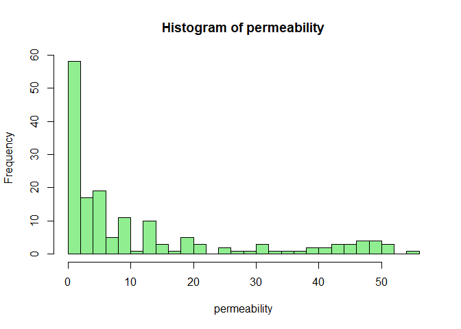

```r
# histogram
hist(permeability,breaks=20,col="lightgreen")
```

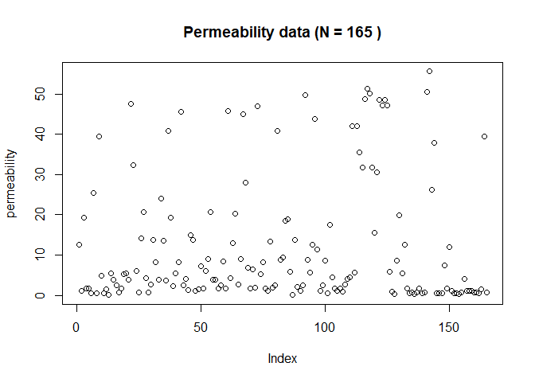

```r
# scatterplot
mainlabel=paste("Permeability data (N =",N,")")
plot(permeability,main=mainlabel)
```

The above data is heavily skewed to the right.  
Additionally, all of the values for permeability are positive.

Therefore, we should consider **fitting the log** of the permeability data.  
This would ensure that our predicted values are also positive, once we **exponentiate the log results**.

#### examine the log(permeability)

```r
log_permeability = log(permeability)
colnames(log_permeability) <- "log(permeability)"
rbind(summary(log_permeability),
      paste0("StDev  : ",round(sd(log_permeability),2),"  "),
      paste0("Skew   :",round(skewness(log_permeability),2),"  ")) %>%
      as.table()
```

```
##  log(permeability)
##  Min.   :-2.8134
##  1st Qu.: 0.4383
##  Median : 1.5913
##  Mean   : 1.5464
##  3rd Qu.: 2.7389
##  Max.   : 4.0182
##  StDev  : 1.53
##  Skew   :-0.13
```

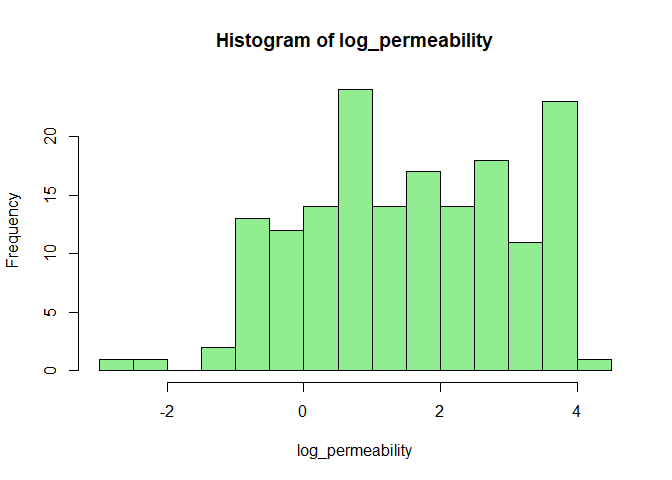

```r
# histogram
hist(log_permeability,breaks=20,col="lightgreen")
```

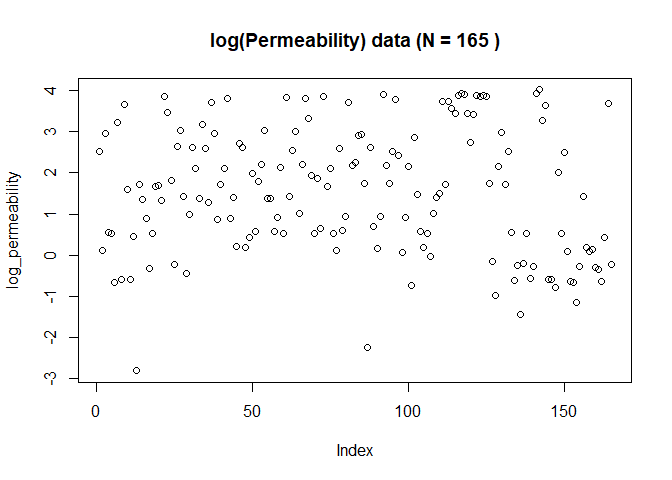

```r
# scatterplot
mainlabel=paste("log(Permeability) data (N =",N,")")
plot(log_permeability,main=mainlabel)
```

### (b) The fingerprint predictors

#### indicate the presence or absence of substructures of a molecule and are often sparse meaning that relatively few of the molecules contain each substructure.

#### Filter out the predictors that have low frequencies using the `nearZeroVar` function from the `caret` package.

```r
fingerprints_nearZeroVarCols <- nearZeroVar( fingerprints)
fingerprints_nTotalCols <- ncol(fingerprints)
fingerprints_nDropCols <- length(fingerprints_nearZeroVarCols)
fingerprints_filtered1 <- fingerprints[,-fingerprints_nearZeroVarCols]
fingerprints_nFiltered <- ncol(fingerprints_filtered1)
dim(fingerprints_filtered1)
```

```
## [1] 165 388
```

#### How many predictors are left for modeling?

There are 719 columns with nearZeroVar out of 1107, leaving a total of 388 remaining, but there are high correlations between numerous columns.

#### Check for high correlations between columns in the fingerprints_filtered data set:

```r
correl1 <- cor(fingerprints_filtered1)

# determinant is zero -- indicates correlation matrix is singular.
print(paste("Determinant: ", det(correl1)))
```

```
## [1] "Determinant:  0"
```

```r
# many columns are identical to other columns.
maxcor1 <- max(correl1-diag(1,ncol(correl1),ncol(correl1)))
mincor1 <- min(correl1-diag(1,ncol(correl1),ncol(correl1)))
print(paste("Range of off-diag correlations: ",
            paste0("[",mincor1,",",maxcor1,"]"), "on",ncol(correl1),"columns"))
```

```
## [1] "Range of off-diag correlations:  [-1,1] on 388 columns"
```

```r
# eliminate columns which are identical to other columns
cutoff = 0.999999999
identicals <- findCorrelation(correl1,cutoff = cutoff)
num_identicals <- length(identicals)
print(paste("Quantity of columns which have identical correlation values:",
            num_identicals, "out of",ncol(correl1)))
```

```
## [1] "Quantity of columns which have identical correlation values: 233 out of 388"
```

```r
# drop columns which are identical to some other column
fingerprints_filtered2 <- fingerprints_filtered1[,-identicals]
dim(fingerprints_filtered2)
```

```
## [1] 165 155
```

```r
print(paste("Remaining number of columns: ", ncol(fingerprints_filtered2)))
```

```
## [1] "Remaining number of columns:  155"
```

```r
# examine correlations on the reduced matrix
correl2 <- cor(fingerprints_filtered2)
maxcor2 <- round(max(correl2-diag(1,ncol(correl2),ncol(correl2))),5)
mincor2 <- round(min(correl2-diag(1,ncol(correl2),ncol(correl2))),5)
print(paste("Range of off-diag correlations: ",
            paste0("[",mincor2,",",maxcor2,"]"), "on",ncol(correl2),"columns"))
```

```
## [1] "Range of off-diag correlations:  [-0.93315,0.98735] on 155 columns"
```

```r
# determinant is still zero - matrix is singular
print(paste("Determinant: ", det(correl2)))
```

```
## [1] "Determinant:  0"
```

#### Correlation grid #1

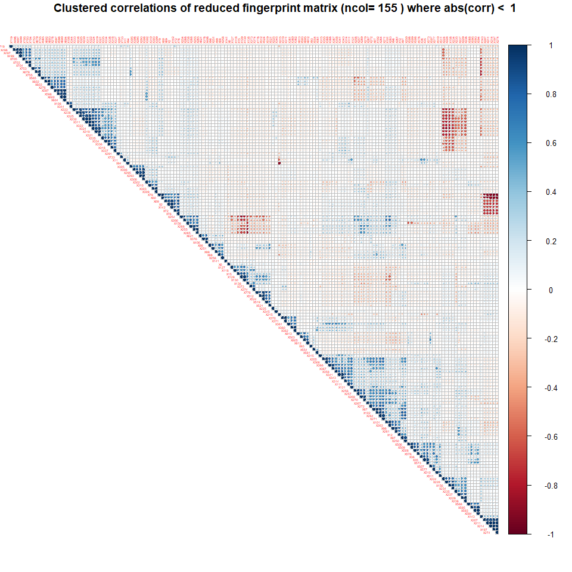

```r
### be sure to specify corrplot::corrplot because the namespace may be masked by pls::corrplot
corrplot::corrplot(
  correl2,
  method = "circle",
  type = "upper",
  order = "hclust",
  tl.cex = 0.3,
  main = paste("\nClustered correlations of reduced fingerprint matrix (ncol=",
               ncol(correl2),") where abs(corr) < ", round(cutoff,4))
)
```

There are still clusters of columns with very high correlations, so let’s remove more columns.

#### identify columns with high correlations, and remove

```r
cutoff = 0.8
high_correl_cols <- findCorrelation(correl1,cutoff = cutoff)
num_high_correl_cols <- length(high_correl_cols)
print(paste("Quantity of columns which have abs(correlation) > ", cutoff ,":",
            num_high_correl_cols, "out of",ncol(correl1)))
```

```
## [1] "Quantity of columns which have abs(correlation) >  0.8 : 318 out of 388"
```

```r
fingerprints_filtered3 <- fingerprints_filtered1[,-high_correl_cols]
dim(fingerprints_filtered3)
```

```
## [1] 165  70
```

```r
print(paste("Remaining number of columns: ", ncol(fingerprints_filtered3)))
```

```
## [1] "Remaining number of columns:  70"
```

```r
correl3 <- cor(fingerprints_filtered3)

maxcor3 <- round(max(correl3-diag(1,ncol(correl3),ncol(correl3))),5)
mincor3 <- round(min(correl3-diag(1,ncol(correl3),ncol(correl3))),5)
print(paste("Range of off-diag correlations: ", paste0("[",mincor3,",",maxcor3,"]"), "on",ncol(correl3),"columns"))
```

```
## [1] "Range of off-diag correlations:  [-0.73139,0.79436] on 70 columns"
```

```r
### Determinant is (barely) nonzero
print(paste("Determinant: ", det(correl3)))
```

```
## [1] "Determinant:  -0.00000000000000000000000000000000000000000000000000000000000000000000000000079713455627643"
```

#### Correlation grid #2

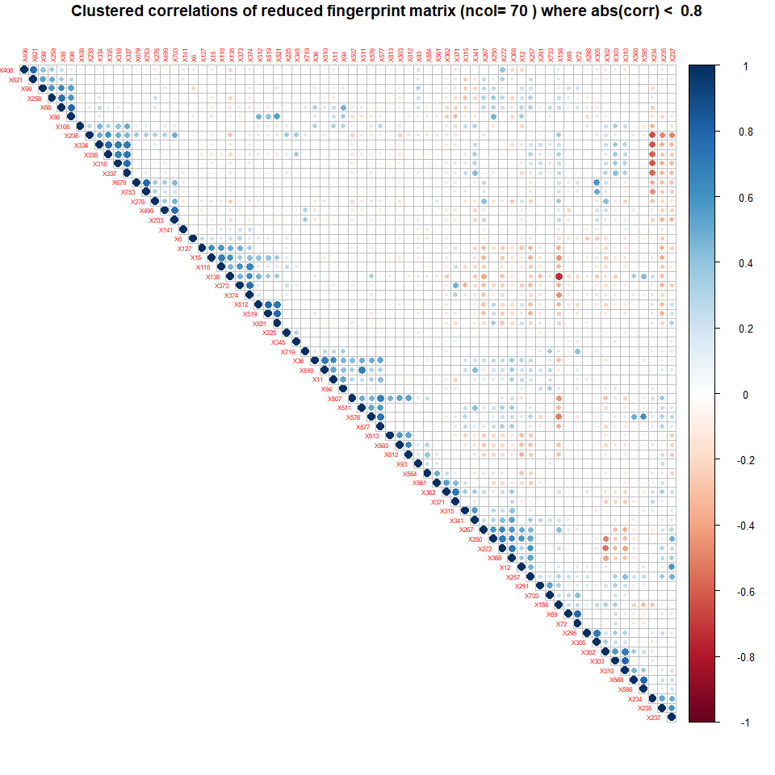

```r
### be sure to specify corrplot::corrplot because the namespace may be masked by pls::corrplot
corrplot::corrplot(
  correl3,
  method = "circle",
  type = "upper",
  order = "hclust",
  tl.cex = 0.5,
  main = paste("\nClustered correlations of reduced fingerprint matrix (ncol=",
               ncol(correl3),") where abs(corr) < ", round(cutoff,4))
)
```

The above correlation grid does not display as many clusters indicating variables that are highly correlated with each other, which should remove the multicollinearlty problem.

### (c) Split, pre-process, and tune

#### pre-process the data

The values for permeability are all positive.

In order to ensure that we do not obtain any negative predictions,  
##### we will fit $\log(permeability)$ and then exponentiate the results of the fitting.

#### Now split the reduced data into a training and a test set,

```r
set.seed(12345)
trainRow <- createDataPartition(log_permeability, p=0.8, list=FALSE)
ctrl <- trainControl(method = "cv")


fingerprints.train     <- fingerprints_filtered3[trainRow, ]
permeability.train     <- permeability[trainRow, ]
log_permeability.train <- log_permeability[trainRow, ]
fingerprints.test      <- fingerprints_filtered3[-trainRow, ]
permeability.test      <- permeability[-trainRow, ]
log_permeability.test  <- log_permeability[-trainRow, ]
```

#### and tune a PLS model.

```r
#library(pls)
## Run PLS
set.seed(100)
plsTune <- train(x = fingerprints.train,
                 y = log_permeability.train,
                 method = "pls",
                 metric='Rsquared',
                 tuneLength = 25,
                 tuneGrid = expand.grid(ncomp = 1:25),
                 trControl = ctrl,
                 preProcess=c('center', 'scale')
                 )
plsTune
```

```
## Partial Least Squares
##
## 133 samples
##  70 predictor
##
## Pre-processing: centered (70), scaled (70)
## Resampling: Cross-Validated (10 fold)
## Summary of sample sizes: 120, 120, 119, 121, 120, 119, ...
## Resampling results across tuning parameters:
##
##   ncomp  RMSE      Rsquared   MAE
##    1     1.129601  0.4468554  0.9303761
##    2     1.074201  0.5448874  0.8641737
##    3     1.035358  0.5872487  0.8454854
##    4     1.023068  0.5958865  0.8085643
##    5     1.015558  0.5978475  0.8150107
##    6     1.034142  0.5840170  0.8297577
##    7     1.058789  0.5656890  0.8495580
##    8     1.082135  0.5516989  0.8697853
##    9     1.097500  0.5458186  0.8811166
##   10     1.110163  0.5339912  0.8972611
##   11     1.096836  0.5448363  0.8925973
##   12     1.094091  0.5464926  0.8881003
##   13     1.096872  0.5485320  0.8813345
##   14     1.091911  0.5523404  0.8805000
##   15     1.104452  0.5492240  0.8893918
##   16     1.125506  0.5360055  0.9159197
##   17     1.128329  0.5360832  0.9165264
##   18     1.132735  0.5317496  0.9149671
##   19     1.134723  0.5310171  0.9105706
##   20     1.133074  0.5323104  0.9099273
##   21     1.150676  0.5209886  0.9314301
##   22     1.166670  0.5121152  0.9443104
##   23     1.186409  0.4999861  0.9565978
##   24     1.194800  0.4964499  0.9626836
##   25     1.203732  0.4918587  0.9702770
##
## Rsquared was used to select the optimal model using the largest value.
## The final value used for the model was ncomp = 5.
```

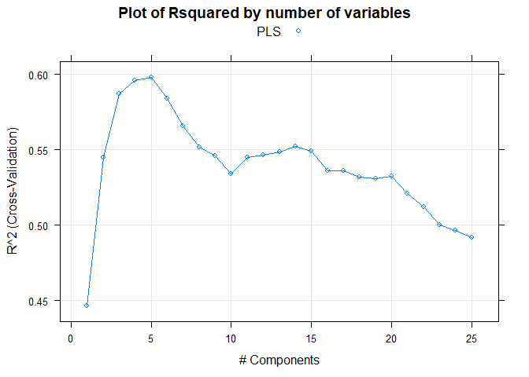

```r
plsResamples <- plsTune$results
plsResamples$Model <- "PLS"

xyplot(Rsquared ~ ncomp,
       data = plsResamples,
       #aspect = 1,
       xlab = "# Components",
       ylab = "R^2 (Cross-Validation)",
       auto.key = list(),
       groups = Model,
       type = c("o", "g"),
       main="Plot of Rsquared by number of variables")
```

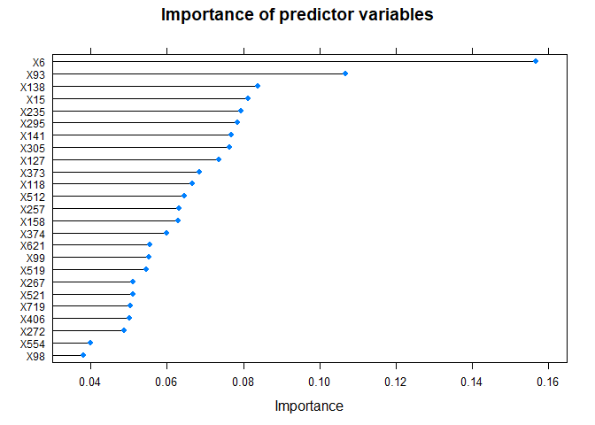

```r
#### Importance plot of predictor variables
plsImp <- varImp(plsTune, scale = FALSE)
plot(plsImp, top = 25,
     scales = list(y = list(cex = .75)),
     main="Importance of predictor variables")
```

#### How many latent variables are optimal and what is the corresponding resampled estimate of R2?

```r
plsTune$bestTune$ncomp
```

```
## [1] 5
```

```r
plsTune$results[plsTune$bestTune$ncomp,]
```

```
##   ncomp     RMSE  Rsquared       MAE    RMSESD RsquaredSD    MAESD
## 5     5 1.015558 0.5978475 0.8150107 0.2109767  0.1541557 0.149285
```

The optimal number of latent variables is 5 and the corresponding resampled estimate of $R^2$ is 0.5978475 .

### (d) Predict the response for the test set.

#### Predict the log(permeability)

```r
#### We have predicted the log of permeability
log_pls_test_y_hat <- predict(object = plsTune, newdata = fingerprints.test   )
log_pls_test_stats <- postResample(pred = log_pls_test_y_hat, obs = log_permeability.test)
(log_pls_test_stats <- rbind(log_pls_test_stats)) %>%
  kable() %>%
  kable_styling(c("bordered","striped"),full_width = F)
```

|  | RMSE | Rsquared | MAE |
| --- | --- | --- | --- |
| log_pls_test_stats | 1.261313 | 0.4465345 | 0.9552875 |

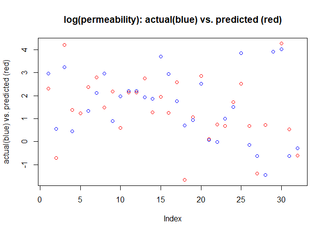

```r
# Plot actual and predicted permeability by index
plot(log_pls_test_y_hat,col="red",
     ylab="actual(blue) vs. predicted (red)",
     main="log(permeability): actual(blue) vs. predicted (red)")
points(log_permeability.test,col="blue")
```

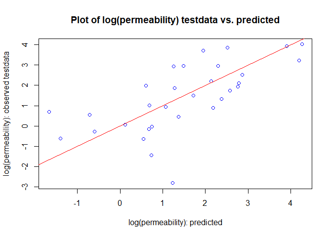

```r
#### Plot of log(observed) vs. log(predicted)
main=paste("Plot of log(permeability)",
            "testdata vs. predicted")
plot(log_permeability.test~log_pls_test_y_hat,
     main=main,col="blue",
     ylab="log(permeability): observed testdata",
     xlab="log(permeability): predicted")
abline(a=0,b=1,col="red")
```

#### Because we predicted the **log** of the permeability, **exponentiate** to get the genuine value

```r
pls_test_y_hat <- exp(log_pls_test_y_hat)
pls_test_stats <- postResample(pred = pls_test_y_hat, obs = permeability.test)
(pls_test_stats <- rbind(pls_test_stats)) %>%
  kable() %>%
  kable_styling(c("bordered","striped"),full_width = F)
```

|  | RMSE | Rsquared | MAE |
| --- | --- | --- | --- |
| pls_test_stats | 12.79551 | 0.4969029 | 7.340892 |

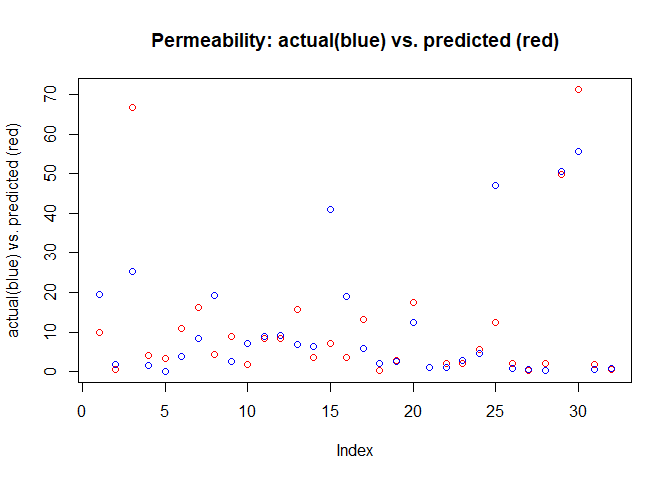

```r
# Plot actual and predicted permeability by index
plot(pls_test_y_hat,col="red",
     ylab="actual(blue) vs. predicted (red)",
     main="Permeability: actual(blue) vs. predicted (red)")
points(permeability.test,col="blue")
```

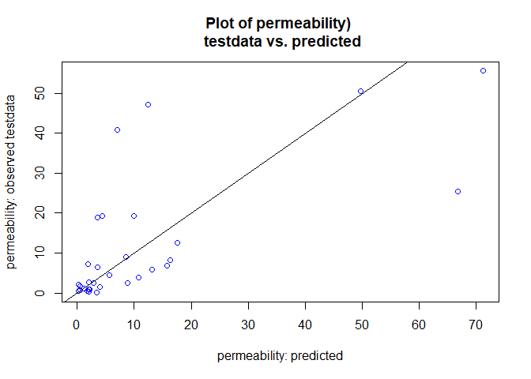

```r
main=paste("Plot of permeability)","\n",
            "testdata vs. predicted")
plot(permeability.test~ pls_test_y_hat,
     main=main,col="blue",
     ylab="permeability: observed testdata",
     xlab="permeability: predicted")
abline(a=0,b=1)
```

#### What is the test set estimate of R2?

The test set estimate of $R^2$ is 0.4969029 .

#### Plot results in log space

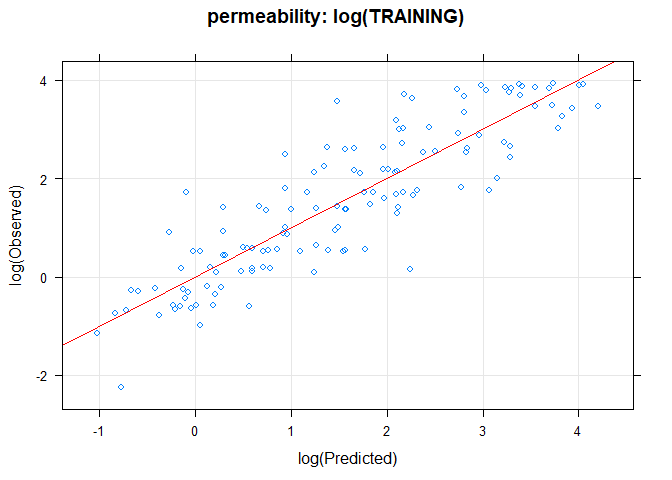

```r
par(mfrow=c(1,2))
xyplot(log_permeability.train ~ predict(plsTune),
## plot the points (type = 'p') and a background grid ('g')
type = c("p", "g"),
xlab = "log(Predicted)", ylab = "log(Observed)", main="permeability: log(TRAINING)",
panel = function(x,y, ...){
  panel.xyplot(x,y, ...)
  panel.abline(a=0,b=1,col="red")
  }
)
```

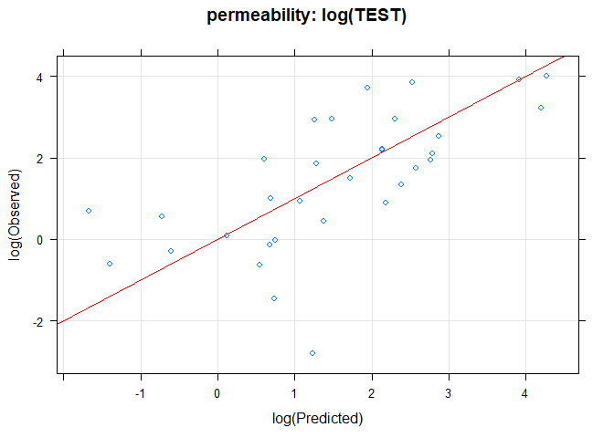

```r
xyplot(log_permeability.test ~ predict(plsTune,newdata = fingerprints.test),
## plot the points (type = 'p') and a background grid ('g')
type = c("p", "g"),
xlab = "log(Predicted)", ylab = "log(Observed)", main="permeability: log(TEST)",
panel = function(x,y, ...){
  panel.xyplot(x,y, ...)
  panel.abline(a=0,b=1,col="red")
  }
)
```

#### Plot results transformed back from log space

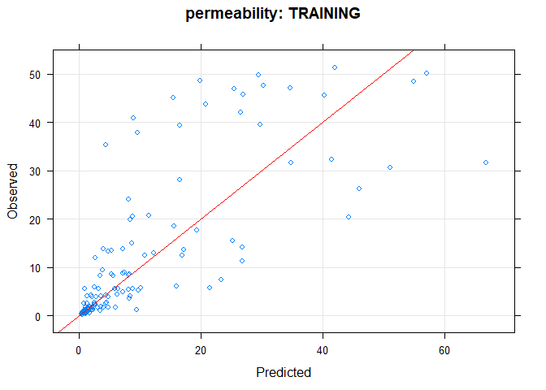

```r
par(mfrow=c(1,2))
xyplot(permeability.train ~ exp(predict(plsTune)),
## plot the points (type = 'p') and a background grid ('g')
type = c("p", "g"),
xlab = "Predicted", ylab = "Observed", main="permeability: TRAINING",
panel = function(x,y, ...){
  panel.xyplot(x,y, ...)
  panel.abline(a=0,b=1,col="red")
  }
)
```

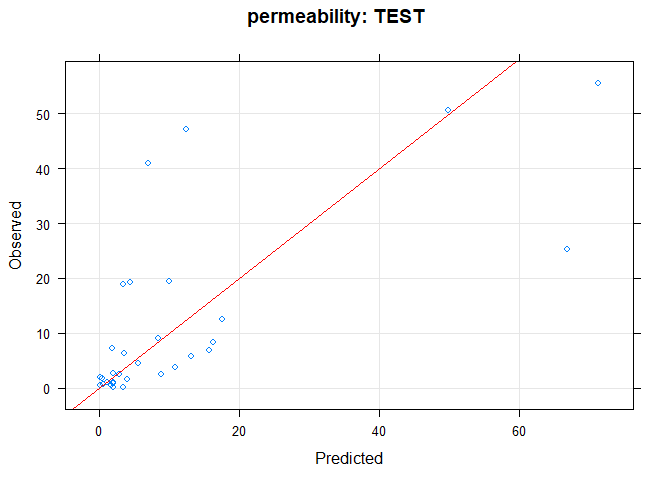

```r
xyplot(permeability.test ~ exp(predict(plsTune,newdata = fingerprints.test)),
## plot the points (type = 'p') and a background grid ('g')
type = c("p", "g"),
xlab = "Predicted", ylab = "Observed", main="permeability: TEST",
panel = function(x,y, ...){
  panel.xyplot(x,y, ...)
  panel.abline(a=0,b=1,col="red")
  }
)
```

#### Plot the residuals

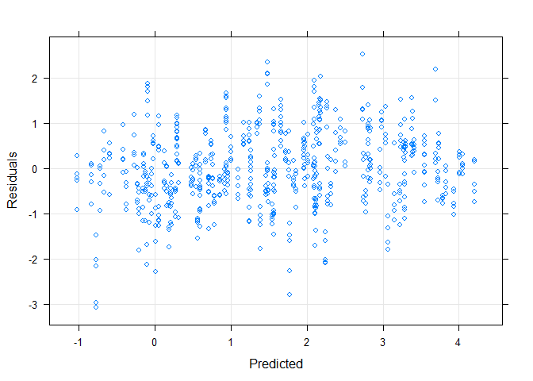

```r
xyplot(resid(plsTune) ~ predict(plsTune),
type = c("p", "g"),
xlab = "Predicted", ylab = "Residuals")
```

### (e) Try building other models discussed in this chapter.

#### Principal Components Regression

```r
set.seed(100)
pcrTune <- train(x = fingerprints.train,
                 y = log_permeability.train,
                 method = "pcr",
                 metric='Rsquared',
                 tuneLength = 30,
                 tuneGrid = expand.grid(ncomp = 1:30),
                 trControl = ctrl,
                 preProcess=c('center', 'scale')
                 )
pcrTune
```

```
## Principal Component Analysis
##
## 133 samples
##  70 predictor
##
## Pre-processing: centered (70), scaled (70)
## Resampling: Cross-Validated (10 fold)
## Summary of sample sizes: 120, 120, 119, 121, 120, 119, ...
## Resampling results across tuning parameters:
##
##   ncomp  RMSE      Rsquared   MAE
##    1     1.396449  0.1921303  1.1885866
##    2     1.407526  0.1628107  1.2076770
##    3     1.258203  0.3136725  1.0753989
##    4     1.249699  0.3191919  1.0674092
```

[output cut: 29 more lines]

```r
pcrTune$bestTune$ncomp
```

```
## [1] 29
```

```r
pcrTune$results[pcrTune$bestTune$ncomp,]
```

```
##    ncomp     RMSE  Rsquared       MAE    RMSESD RsquaredSD     MAESD
## 29    29 0.997372 0.6158315 0.7872849 0.1835222  0.1404608 0.1290529
```

```r
log_pcr_test_y_hat <- predict(object = pcrTune, newdata = fingerprints.test   )
log_pcr_test_stats <- postResample(pred = log_pcr_test_y_hat, obs = log_permeability.test)
(log_pcr_test_stats <- rbind(log_pcr_test_stats))
```

```
##                        RMSE  Rsquared       MAE
## log_pcr_test_stats 1.222122 0.4707882 0.9254839
```

```r
pcr_test_y_hat <- exp(log_pcr_test_y_hat)
pcr_test_stats <- postResample(pred = pcr_test_y_hat, obs = permeability.test)
(pcr_test_stats <- rbind(pcr_test_stats)) %>%
  kable() %>%
  kable_styling(c("bordered","striped"),full_width = F)
```

|  | RMSE | Rsquared | MAE |
| --- | --- | --- | --- |
| pcr_test_stats | 11.05509 | 0.5091551 | 6.912708 |

#### Ridge Regression

```r
ridgeGrid <- data.frame(.lambda = seq(0, 1, length = 101))
set.seed(100)
ridgeTune <- train(x = fingerprints.train,
                   y = log_permeability.train,
                   method = "ridge",
                   metric='Rsquared',
## Fit the model over many penalty values
                   tuneGrid = ridgeGrid,
                   trControl = ctrl,
## put the predictors on the same scale
                   preProc = c("center", "scale"))
ridgeTune
```

```
## Ridge Regression
##
## 133 samples
##  70 predictor
##
## Pre-processing: centered (70), scaled (70)
## Resampling: Cross-Validated (10 fold)
## Summary of sample sizes: 120, 120, 119, 121, 120, 119, ...
## Resampling results across tuning parameters:
##
##   lambda  RMSE      Rsquared   MAE
##   0.00    2.397076  0.4316102  1.3197444
##   0.01    1.071955  0.5584276  0.8561084
##   0.02    1.052839  0.5718695  0.8396762
##   0.03    1.045033  0.5778364  0.8378414
##   0.04    1.040172  0.5819314  0.8362268
##   0.05    1.036598  0.5852476  0.8341247
##   0.06    1.033790  0.5881104  0.8320177
##   0.07    1.031524  0.5906508  0.8297302
##   0.08    1.029681  0.5929363  0.8273909
##   0.09    1.028187  0.5950079  0.8254853
##   0.10    1.026992  0.5968944  0.8245605
##   0.11    1.026057  0.5986173  0.8235870
##   0.12    1.025354  0.6001937  0.8227112
##   0.13    1.024859  0.6016377  0.8218256
##   0.14    1.024552  0.6029610  0.8213229
##   0.15    1.024417  0.6041740  0.8210594
##   0.16    1.024440  0.6052854  0.8207994
##   0.17    1.024610  0.6063031  0.8205479
##   0.18    1.024915  0.6072341  0.8203080
##   0.19    1.025346  0.6080846  0.8200821
##   0.20    1.025896  0.6088602  0.8198715
##   0.21    1.026558  0.6095661  0.8196772
##   0.22    1.027324  0.6102069  0.8194994
##   0.23    1.028190  0.6107869  0.8195686
##   0.24    1.029149  0.6113101  0.8201114
##   0.25    1.030198  0.6117800  0.8206684
##   0.26    1.031331  0.6122001  0.8212393
##   0.27    1.032546  0.6125733  0.8218234
##   0.28    1.033838  0.6129027  0.8225941
```

[output cut: 60 more lines]

```
##   0.89    1.190129  0.6012167  0.9667778
##   0.90    1.193362  0.6008692  0.9694900
##   0.91    1.196605  0.6005214  0.9721917
##   0.92    1.199859  0.6001734  0.9748830
##   0.93    1.203122  0.5998253  0.9776347
##   0.94    1.206394  0.5994772  0.9803794
##   0.95    1.209675  0.5991290  0.9831136
##   0.96    1.212965  0.5987810  0.9858681
##   0.97    1.216263  0.5984331  0.9887185
##   0.98    1.219569  0.5980855  0.9915969
##   0.99    1.222882  0.5977381  0.9944956
##   1.00    1.226204  0.5973910  0.9973876
##
## Rsquared was used to select the optimal model using the largest value.
## The final value used for the model was lambda = 0.38.
```

```r
ridgeTune$bestTune$lambda
```

```
## [1] 0.38
```

```r
ridgeTune$results[rownames(ridgeTune$bestTune),]
```

```
##    lambda     RMSE  Rsquared       MAE    RMSESD RsquaredSD     MAESD
## 39   0.38 1.050361 0.6142911 0.8351124 0.2394788  0.1645513 0.1630461
```

```r
log_ridge_test_y_hat <- predict(object = ridgeTune, newdata = fingerprints.test   )
log_ridge_test_stats <- postResample(pred = log_ridge_test_y_hat, obs = log_permeability.test)
(log_ridge_test_stats <- rbind(log_ridge_test_stats))
```

```
##                          RMSE  Rsquared       MAE
## log_ridge_test_stats 1.245917 0.5000962 0.9837901
```

```r
ridge_test_y_hat <- exp(log_ridge_test_y_hat)
ridge_test_stats <- postResample(pred = ridge_test_y_hat, obs = permeability.test)
(ridge_test_stats <- rbind(ridge_test_stats)) %>%
  kable() %>%
  kable_styling(c("bordered","striped"),full_width = F)
```

|  | RMSE | Rsquared | MAE |
| --- | --- | --- | --- |
| ridge_test_stats | 17.63038 | 0.5331787 | 10.12143 |

#### Elasticnet

```r
enetGrid = expand.grid(.lambda  =seq(0,    1,   length=21),
                       .fraction=seq(0.05, 1.0, length=20))
set.seed(100)
enetTune <- train(x = fingerprints.train,
                  y = log_permeability.train,
                  method = "enet",
                  metric='Rsquared',
                  tuneGrid = enetGrid,
                  trControl = ctrl,
                  preProc = c("center", "scale")
                  )
# enetTune
## printing suppressed because of length of results:

## Rsquared was used to select the optimal model using the largest value.
## The final values used for the model were fraction = 0.5 and lambda = 0.45.

enetTune$bestTune
```

```
##     fraction lambda
## 190      0.5   0.45
```

```r
enetTune$results[rownames(enetTune$bestTune),]
```

```
##     lambda fraction      RMSE  Rsquared       MAE    RMSESD RsquaredSD
## 190   0.45      0.5 0.9782374 0.6339662 0.7726211 0.1649071  0.1244465
##         MAESD
## 190 0.1105195
```

```r
log_enet_test_y_hat <- predict(object = enetTune, newdata = fingerprints.test   )
log_enet_test_stats <- postResample(pred = log_enet_test_y_hat, obs = log_permeability.test)
(log_enet_test_stats <- rbind(log_enet_test_stats))
```

```
##                         RMSE  Rsquared       MAE
## log_enet_test_stats 1.153593 0.5134051 0.8594702
```

```r
enet_test_y_hat <- exp(log_enet_test_y_hat)
enet_test_stats <- postResample(pred = enet_test_y_hat, obs = permeability.test)
(enet_test_stats <- rbind(enet_test_stats)) %>%
  kable() %>%
  kable_styling(c("bordered","striped"),full_width = F)
```

|  | RMSE | Rsquared | MAE |
| --- | --- | --- | --- |
| enet_test_stats | 12.90858 | 0.4408179 | 7.388419 |

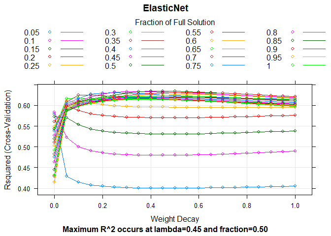

```r
plot(enetTune, main="ElasticNet", sub="Maximum R^2 occurs at lambda=0.45 and fraction=0.50")
```

#### Do any have better predictive performance?

```r
rbind(pls_test_stats,pcr_test_stats,ridge_test_stats,enet_test_stats ) %>%
  kable(caption = "Summary of results") %>%
  kable_styling(c("bordered","striped"),full_width = F)
```

Summary of results

|  | RMSE | Rsquared | MAE |
| --- | --- | --- | --- |
| pls_test_stats | 12.79551 | 0.4969029 | 7.340892 |
| pcr_test_stats | 11.05509 | 0.5091551 | 6.912708 |
| ridge_test_stats | 17.63038 | 0.5331787 | 10.121428 |
| enet_test_stats | 12.90858 | 0.4408179 | 7.388419 |

**Ridge** has a better $R^2$, but this result corresponds to a worse RMSE and MAE.  
Using the criterion of maximizing $R^2$, the associated RMSE and MAE are better on **PCR** than PLS.

### (f) Would you recommend any of your models to replace the permeability laboratory experiment?

No, I don’t believe that the predictive power from these models are strong enough to replace the laboratory experiment.

## 6.3. A chemical manufacturing process for a pharmaceutical product

#### was discussed in Sect. 1.4.

#### In this problem, the objective is to understand the relationship between

- **biological** measurements of the raw materials (predictors),
- measurements of the **manufacturing process** (predictors), and
- the response of **product yield**.

#### **Biological predictors** cannot be changed but can be used to assess the quality of the raw material before processing.

#### On the other hand, **manufacturing process predictors** can be changed in the manufacturing process.

#### Improving product yield by 1% will boost revenue by approximately one hundred thousand dollars per batch:

### (a) Start R and use these commands to load the data:

```r
#library(AppliedPredictiveModeling)
#data(chemicalManufacturing)                  ## The data set has been renamed
data(ChemicalManufacturingProcess)
# save a copy
origChemicalManufacturingProcess <- ChemicalManufacturingProcess
# Examine the data
# summary with standard deviation and skewness:
#library(moments)
### Because all the data is numeric, we can change from data.frame to matrix
m_ChemicalManufacturingProcess <- as.matrix(ChemicalManufacturingProcess)
rbind(summary(m_ChemicalManufacturingProcess),
      paste0("StDev  :",round(apply(X = m_ChemicalManufacturingProcess, MARGIN = 2, FUN = sd,na.rm=T),2),"  "),
      paste0("Skew   :",round(skewness(m_ChemicalManufacturingProcess,na.rm=T),2),"  ")) %>%
      as.table()
```

```
##      Yield       BiologicalMaterial01 BiologicalMaterial02 BiologicalMaterial03
##  Min.   :35.25   Min.   :4.580        Min.   :46.87        Min.   :56.97
##  1st Qu.:38.75   1st Qu.:5.978        1st Qu.:52.68        1st Qu.:64.98
##  Median :39.97   Median :6.305        Median :55.09        Median :67.22
##  Mean   :40.18   Mean   :6.411        Mean   :55.69        Mean   :67.70
##  3rd Qu.:41.48   3rd Qu.:6.870        3rd Qu.:58.74        3rd Qu.:70.43
##  Max.   :46.34   Max.   :8.810        Max.   :64.75        Max.   :78.25
##
##  StDev  :1.85    StDev  :0.71         StDev  :4.03         StDev  :4
##  Skew   :0.31    Skew   :0.28         Skew   :0.25         Skew   :0.03
##  BiologicalMaterial04 BiologicalMaterial05 BiologicalMaterial06
##  Min.   : 9.38        Min.   :13.24        Min.   :40.60
##  1st Qu.:11.24        1st Qu.:17.23        1st Qu.:46.05
##  Median :12.10        Median :18.49        Median :48.46
##  Mean   :12.35        Mean   :18.60        Mean   :48.91
##  3rd Qu.:13.22        3rd Qu.:19.90        3rd Qu.:51.34
##  Max.   :23.09        Max.   :24.85        Max.   :59.38
##
##  StDev  :1.77         StDev  :1.84         StDev  :3.75
##  Skew   :1.75         Skew   :0.31         Skew   :0.37
##  BiologicalMaterial07 BiologicalMaterial08 BiologicalMaterial09
##  Min.   :100.0        Min.   :15.88        Min.   :11.44
##  1st Qu.:100.0        1st Qu.:17.06        1st Qu.:12.60
##  Median :100.0        Median :17.51        Median :12.84
##  Mean   :100.0        Mean   :17.49        Mean   :12.85
##  3rd Qu.:100.0        3rd Qu.:17.88        3rd Qu.:13.13
##  Max.   :100.8        Max.   :19.14        Max.   :14.08
##
##  StDev  :0.11         StDev  :0.68         StDev  :0.42
##  Skew   :7.46         Skew   :0.22         Skew   :-0.27
##  BiologicalMaterial10 BiologicalMaterial11 BiologicalMaterial12
##  Min.   :1.770        Min.   :135.8        Min.   :18.35
##  1st Qu.:2.460        1st Qu.:143.8        1st Qu.:19.73
##  Median :2.710        Median :146.1        Median :20.12
##  Mean   :2.801        Mean   :147.0        Mean   :20.20
##  3rd Qu.:2.990        3rd Qu.:149.6        3rd Qu.:20.75
##  Max.   :6.870        Max.   :158.7        Max.   :22.21
##
##  StDev  :0.6          StDev  :4.82         StDev  :0.77
##  Skew   :2.42         Skew   :0.36         Skew   :0.31
```

[output cut: 135 more lines]

```
##  3rd Qu.:0.00000        3rd Qu.:0.00000        3rd Qu.:11.70
##  Max.   :0.10000        Max.   :0.20000        Max.   :12.10
##  NA's   :1              NA's   :1
##  StDev  :0.04           StDev  :0.05           StDev  :1.94
##  Skew   :1.69           Skew   :2.19           Skew   :-5.5
##  ManufacturingProcess43 ManufacturingProcess44 ManufacturingProcess45
##  Min.   : 0.0000        Min.   :0.000          Min.   :0.000
##  1st Qu.: 0.6000        1st Qu.:1.800          1st Qu.:2.100
##  Median : 0.8000        Median :1.900          Median :2.200
##  Mean   : 0.9119        Mean   :1.805          Mean   :2.138
##  3rd Qu.: 1.0250        3rd Qu.:1.900          3rd Qu.:2.300
##  Max.   :11.0000        Max.   :2.100          Max.   :2.600
##
##  StDev  :0.87           StDev  :0.32           StDev  :0.41
##  Skew   :9.13           Skew   :-5.01          Skew   :-4.11
```

```r
# check rows for NAs
nTotalRows <- nrow(m_ChemicalManufacturingProcess)
nCompleteRows <- sum(completeRows <- complete.cases(m_ChemicalManufacturingProcess))
nRowsWithNA <- nTotalRows - nCompleteRows
print(paste("There are ", nCompleteRows, "Complete Rows and ", nRowsWithNA, "Rows with some NA value, out of ",nTotalRows, "Total Rows"  ))
```

```
## [1] "There are  152 Complete Rows and  24 Rows with some NA value, out of  176 Total Rows"
```

```r
# check columns for NAs
nTotalCols <- ncol(m_ChemicalManufacturingProcess)
colsWithNA <- apply(m_ChemicalManufacturingProcess,2,anyNA)
nColsWithNA <- sum(colsWithNA)
nCompleteCols <- nTotalCols - nColsWithNA
print(paste("There are ", nCompleteCols, "Complete Columns and ", nColsWithNA, "Columns with some NA value, out of ",nTotalCols, "Total Columns"  ))
```

```
## [1] "There are  30 Complete Columns and  28 Columns with some NA value, out of  58 Total Columns"
```

The matrix `ChemicalManufacturingProcess` contains the 57 predictors

- 12 describing the input biological material and
- 45 describing the process predictors) for the 176 manufacturing runs.
- `yield` contains the percent yield for each run.

### (b) Imputation

#### A small percentage of cells in the predictor set contain missing values.

##### Visualize which columns have missing data using VIM::aggr :

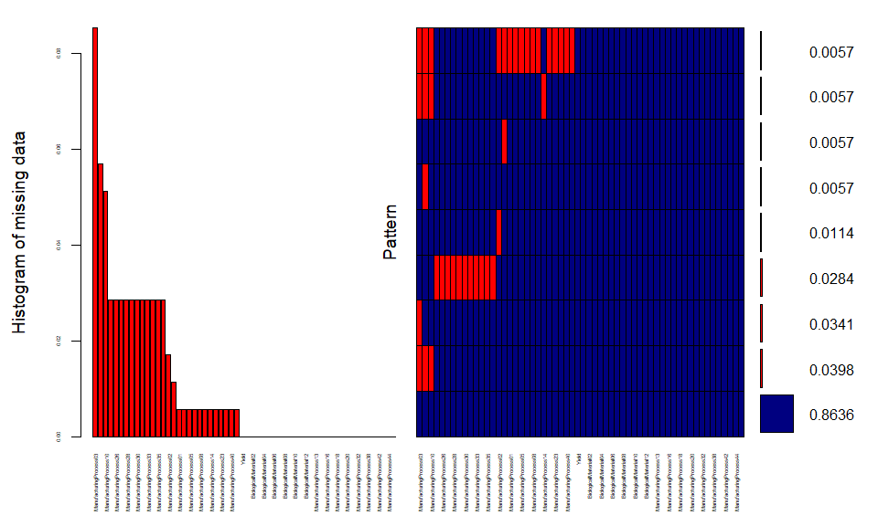

```
##
##  Variables sorted by number of missings:
##                Variable       Count
##  ManufacturingProcess03 0.085227273
##  ManufacturingProcess11 0.056818182
##  ManufacturingProcess10 0.051136364
##  ManufacturingProcess25 0.028409091
##  ManufacturingProcess26 0.028409091
##  ManufacturingProcess27 0.028409091
##  ManufacturingProcess28 0.028409091
##  ManufacturingProcess29 0.028409091
##  ManufacturingProcess30 0.028409091
##  ManufacturingProcess31 0.028409091
##  ManufacturingProcess33 0.028409091
##  ManufacturingProcess34 0.028409091
##  ManufacturingProcess35 0.028409091
##  ManufacturingProcess36 0.028409091
##  ManufacturingProcess02 0.017045455
##  ManufacturingProcess06 0.011363636
##  ManufacturingProcess01 0.005681818
##  ManufacturingProcess04 0.005681818
##  ManufacturingProcess05 0.005681818
##  ManufacturingProcess07 0.005681818
##  ManufacturingProcess08 0.005681818
##  ManufacturingProcess12 0.005681818
##  ManufacturingProcess14 0.005681818
##  ManufacturingProcess22 0.005681818
##  ManufacturingProcess23 0.005681818
##  ManufacturingProcess24 0.005681818
##  ManufacturingProcess40 0.005681818
##  ManufacturingProcess41 0.005681818
##                   Yield 0.000000000
##    BiologicalMaterial01 0.000000000
##    BiologicalMaterial02 0.000000000
##    BiologicalMaterial03 0.000000000
##    BiologicalMaterial04 0.000000000
##    BiologicalMaterial05 0.000000000
##    BiologicalMaterial06 0.000000000
##    BiologicalMaterial07 0.000000000
##    BiologicalMaterial08 0.000000000
##    BiologicalMaterial09 0.000000000
##    BiologicalMaterial10 0.000000000
##    BiologicalMaterial11 0.000000000
##    BiologicalMaterial12 0.000000000
##  ManufacturingProcess09 0.000000000
##  ManufacturingProcess13 0.000000000
##  ManufacturingProcess15 0.000000000
##  ManufacturingProcess16 0.000000000
##  ManufacturingProcess17 0.000000000
##  ManufacturingProcess18 0.000000000
##  ManufacturingProcess19 0.000000000
##  ManufacturingProcess20 0.000000000
##  ManufacturingProcess21 0.000000000
##  ManufacturingProcess32 0.000000000
##  ManufacturingProcess37 0.000000000
##  ManufacturingProcess38 0.000000000
##  ManufacturingProcess39 0.000000000
##  ManufacturingProcess42 0.000000000
##  ManufacturingProcess43 0.000000000
##  ManufacturingProcess44 0.000000000
##  ManufacturingProcess45 0.000000000
```

```r
#library(VIM)
ggr_plot <- aggr(
  origChemicalManufacturingProcess,
  col = c('navyblue', 'red'),
  numbers = TRUE,
  sortVars = TRUE,
  labels = names(origChemicalManufacturingProcess),
  cex.axis = .4,
  gap = 0.5,
  ylab = c("Histogram of missing data", "Pattern")
)
```

#### Use an imputation function to fill in these missing values (e.g., see Sect. 3.8).

##### Use **MICE**: “Multivariate Imputation by Chained Equations” to impute missing values

```r
#library(mice)
imputeChemicalManufacturingProcess <- mice(
  m_ChemicalManufacturingProcess,
  m = 2,
  maxit = 10,
  meth = 'pmm',
  seed = 500,
  print = F
)
ChemicalManufacturingProcess <- complete(imputeChemicalManufacturingProcess)
m_ChemicalManufacturingProcess <- as.matrix(ChemicalManufacturingProcess)

### Any NA values?
anyNA(ChemicalManufacturingProcess)
```

```
## [1] FALSE
```

```r
anyNA(m_ChemicalManufacturingProcess)
```

```
## [1] FALSE
```

```r
##ggpairs(ChemicalManufacturingProcess[,1:10])
```

#### FeaturePlot Loop

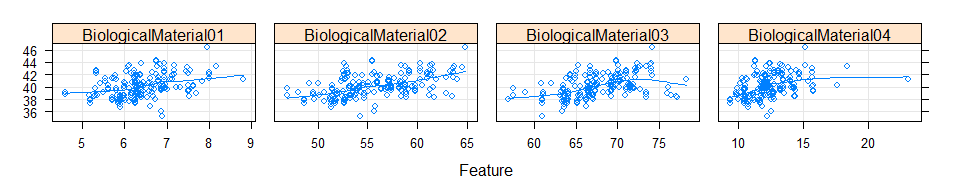

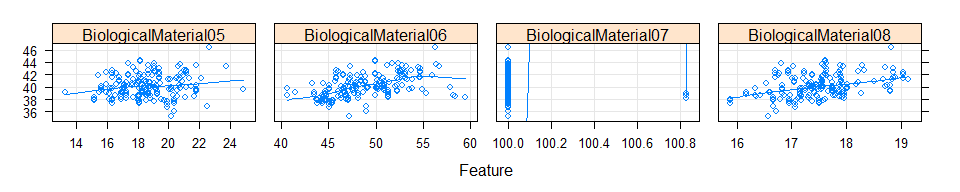

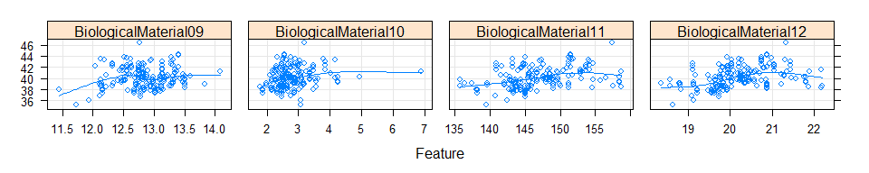

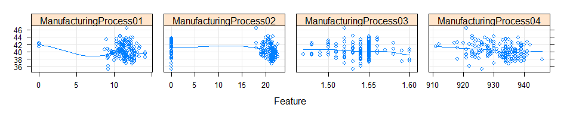

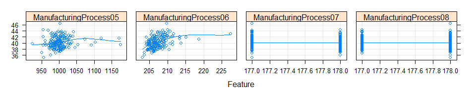

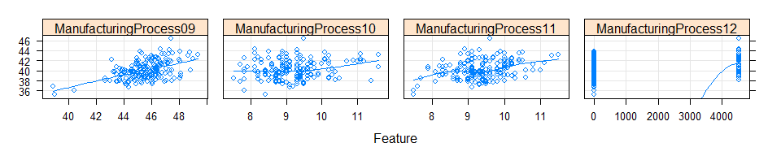

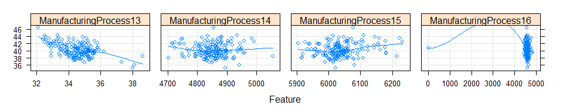

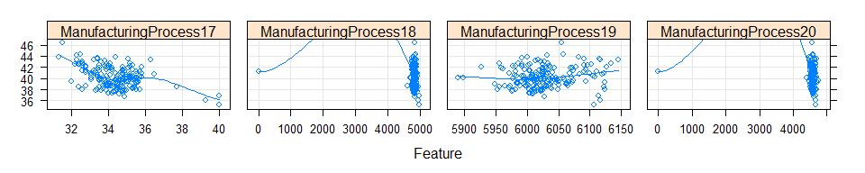

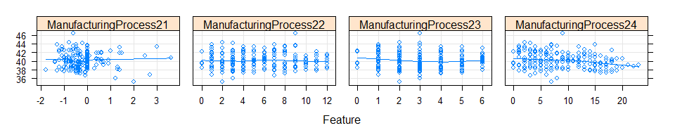

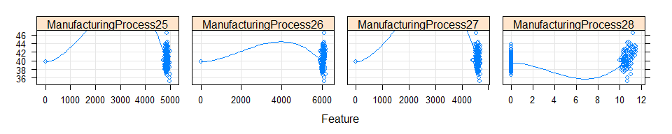

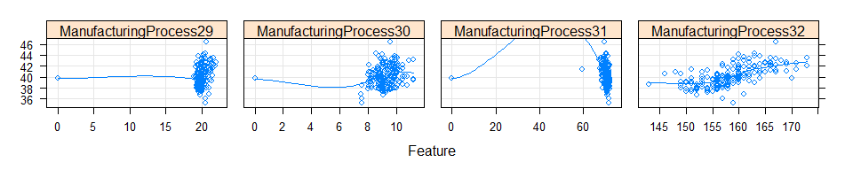

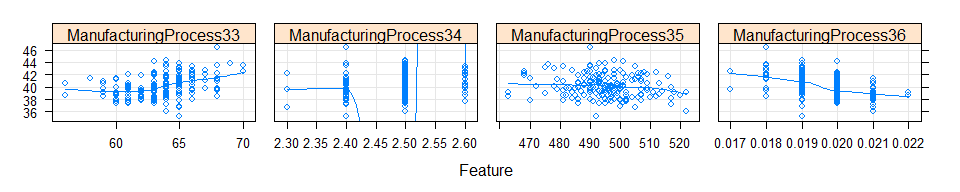

[2 more figures not shown]

```r
for (low in seq(2,54,4)) {
  #print(paste("Range = ", low, " to ", low+3))
print(featurePlot(
  x = m_ChemicalManufacturingProcess[, low:(low+3)],
  y = m_ChemicalManufacturingProcess[, 1],
  between = list(x = 1, y = 1),
  type = c("g", "p", "smooth")
))
}
```

```r
### Above returns a data.frame
### Because all the data is numeric, we can change from data.frame to matrix
m_ChemicalManufacturingProcess <- as.matrix(ChemicalManufacturingProcess)
# Any NA values?
anyNA(m_ChemicalManufacturingProcess)
```

```
## [1] FALSE
```

```r
#### Repeat summary on imputed matrix
rbind(summary(m_ChemicalManufacturingProcess),
      paste0("StDev  :",round(apply(X = m_ChemicalManufacturingProcess, MARGIN = 2, FUN = sd),2),"  "),
      paste0("Skew   :",round(skewness(m_ChemicalManufacturingProcess),2),"  ")) %>%
      as.table()
```

```
##      Yield       BiologicalMaterial01 BiologicalMaterial02 BiologicalMaterial03
##  Min.   :35.25   Min.   :4.580        Min.   :46.87        Min.   :56.97
##  1st Qu.:38.75   1st Qu.:5.978        1st Qu.:52.68        1st Qu.:64.98
##  Median :39.97   Median :6.305        Median :55.09        Median :67.22
##  Mean   :40.18   Mean   :6.411        Mean   :55.69        Mean   :67.70
##  3rd Qu.:41.48   3rd Qu.:6.870        3rd Qu.:58.74        3rd Qu.:70.43
##  Max.   :46.34   Max.   :8.810        Max.   :64.75        Max.   :78.25
##  StDev  :1.85    StDev  :0.71         StDev  :4.03         StDev  :4
##  Skew   :0.31    Skew   :0.28         Skew   :0.25         Skew   :0.03
##  BiologicalMaterial04 BiologicalMaterial05 BiologicalMaterial06
##  Min.   : 9.38        Min.   :13.24        Min.   :40.60
##  1st Qu.:11.24        1st Qu.:17.23        1st Qu.:46.05
##  Median :12.10        Median :18.49        Median :48.46
##  Mean   :12.35        Mean   :18.60        Mean   :48.91
##  3rd Qu.:13.22        3rd Qu.:19.90        3rd Qu.:51.34
##  Max.   :23.09        Max.   :24.85        Max.   :59.38
##  StDev  :1.77         StDev  :1.84         StDev  :3.75
##  Skew   :1.75         Skew   :0.31         Skew   :0.37
##  BiologicalMaterial07 BiologicalMaterial08 BiologicalMaterial09
##  Min.   :100.0        Min.   :15.88        Min.   :11.44
##  1st Qu.:100.0        1st Qu.:17.06        1st Qu.:12.60
##  Median :100.0        Median :17.51        Median :12.84
##  Mean   :100.0        Mean   :17.49        Mean   :12.85
##  3rd Qu.:100.0        3rd Qu.:17.88        3rd Qu.:13.13
##  Max.   :100.8        Max.   :19.14        Max.   :14.08
##  StDev  :0.11         StDev  :0.68         StDev  :0.42
##  Skew   :7.46         Skew   :0.22         Skew   :-0.27
##  BiologicalMaterial10 BiologicalMaterial11 BiologicalMaterial12
##  Min.   :1.770        Min.   :135.8        Min.   :18.35
##  1st Qu.:2.460        1st Qu.:143.8        1st Qu.:19.73
##  Median :2.710        Median :146.1        Median :20.12
##  Mean   :2.801        Mean   :147.0        Mean   :20.20
##  3rd Qu.:2.990        3rd Qu.:149.6        3rd Qu.:20.75
##  Max.   :6.870        Max.   :158.7        Max.   :22.21
##  StDev  :0.6          StDev  :4.82         StDev  :0.77
##  Skew   :2.42         Skew   :0.36         Skew   :0.31
##  ManufacturingProcess01 ManufacturingProcess02 ManufacturingProcess03
##  Min.   : 0.00          Min.   : 0.00          Min.   :1.47
##  1st Qu.:10.80          1st Qu.:19.23          1st Qu.:1.53
##  Median :11.40          Median :21.00          Median :1.54
```

[output cut: 116 more lines]

```
##  Median :0.00000        Median :0.00000        Median :11.60
##  Mean   :0.01761        Mean   :0.02358        Mean   :11.21
##  3rd Qu.:0.00000        3rd Qu.:0.00000        3rd Qu.:11.70
##  Max.   :0.10000        Max.   :0.20000        Max.   :12.10
##  StDev  :0.04           StDev  :0.05           StDev  :1.94
##  Skew   :1.7            Skew   :2.2            Skew   :-5.5
##  ManufacturingProcess43 ManufacturingProcess44 ManufacturingProcess45
##  Min.   : 0.0000        Min.   :0.000          Min.   :0.000
##  1st Qu.: 0.6000        1st Qu.:1.800          1st Qu.:2.100
##  Median : 0.8000        Median :1.900          Median :2.200
##  Mean   : 0.9119        Mean   :1.805          Mean   :2.138
##  3rd Qu.: 1.0250        3rd Qu.:1.900          3rd Qu.:2.300
##  Max.   :11.0000        Max.   :2.100          Max.   :2.600
##  StDev  :0.87           StDev  :0.32           StDev  :0.41
##  Skew   :9.13           Skew   :-5.01          Skew   :-4.11
```